# Project

## Assumptions

```r
# calculate predicted probabilities for each observation
predprobs <- data.frame(predict(final.model,type="probs"))
predprobs %>% filter(row_number() <= 3) # print predictions for first three observations
```

```
##            X3         X4        X5        X6         X7           X8
## 1 0.017495342 0.09414390 0.7238446 0.1532264 0.01073962 0.0005501777
## 2 0.009359913 0.05315181 0.6668244 0.2495969 0.02003058 0.0010363908
## 3 0.007671708 0.04406574 0.6362351 0.2864007 0.02436044 0.0012663181
```

```r
# calculate residuals
data <- data %>% mutate(resid3 = qua3-predprobs[,1],
                        resid4 = qua4-predprobs[,2],
                        resid5 = qua5-predprobs[,3],
                        resid6 = qua6-predprobs[,4],
                        resid7 = qua7-predprobs[,5],
                        resid8 = qua8-predprobs[,6])
```

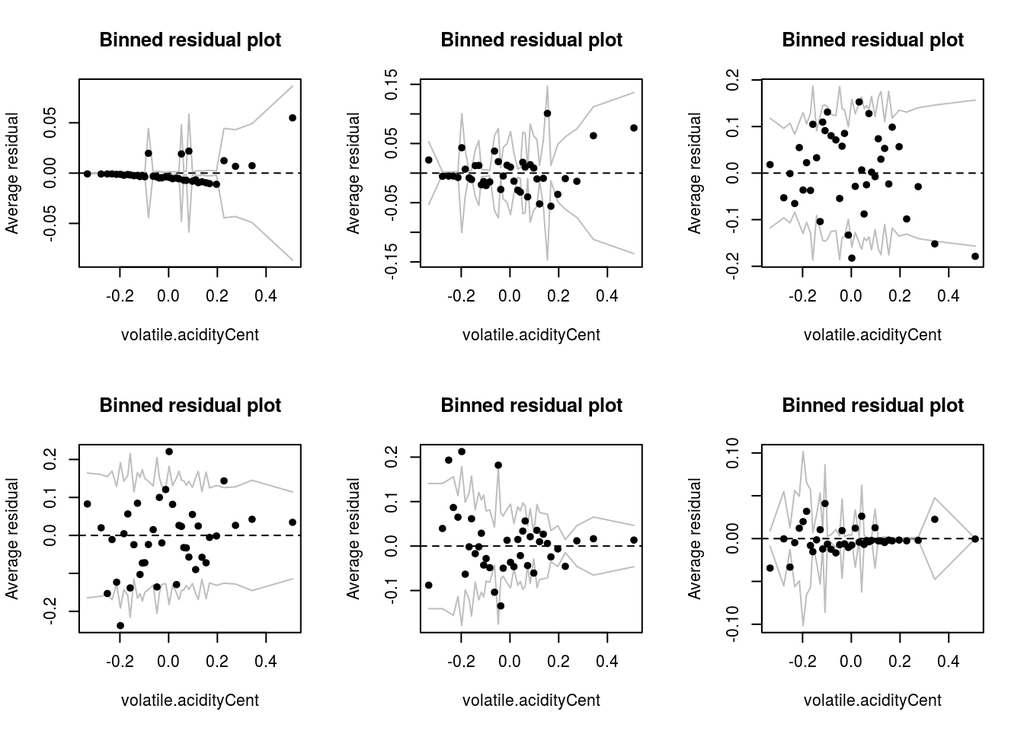

```r
# binned residual plots of volatile.acidityCent for each category of quality
par(mfrow=c(2,3))
arm::binnedplot(x=data$volatile.acidityCent,y=data$resid3,xlab="volatile.acidityCent")
arm::binnedplot(x=data$volatile.acidityCent,y=data$resid4,xlab="volatile.acidityCent")
arm::binnedplot(x=data$volatile.acidityCent,y=data$resid5,xlab="volatile.acidityCent")
arm::binnedplot(x=data$volatile.acidityCent,y=data$resid6,xlab="volatile.acidityCent")
arm::binnedplot(x=data$volatile.acidityCent,y=data$resid7,xlab="volatile.acidityCent")
arm::binnedplot(x=data$volatile.acidityCent,y=data$resid8,xlab="volatile.acidityCent")
```

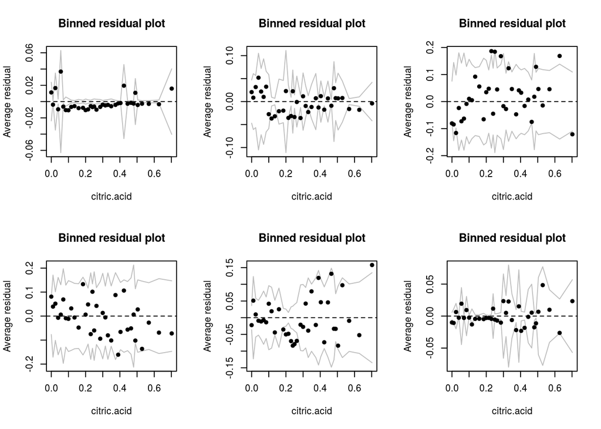

```r
# binned residual plots of citric.acid for each category of quality
par(mfrow=c(2,3))
arm::binnedplot(x=data$citric.acid,y=data$resid3,xlab="citric.acid")
arm::binnedplot(x=data$citric.acid,y=data$resid4,xlab="citric.acid")
arm::binnedplot(x=data$citric.acid,y=data$resid5,xlab="citric.acid")
arm::binnedplot(x=data$citric.acid,y=data$resid6,xlab="citric.acid")
arm::binnedplot(x=data$citric.acid,y=data$resid7,xlab="citric.acid")
arm::binnedplot(x=data$citric.acid,y=data$resid8,xlab="citric.acid")
```

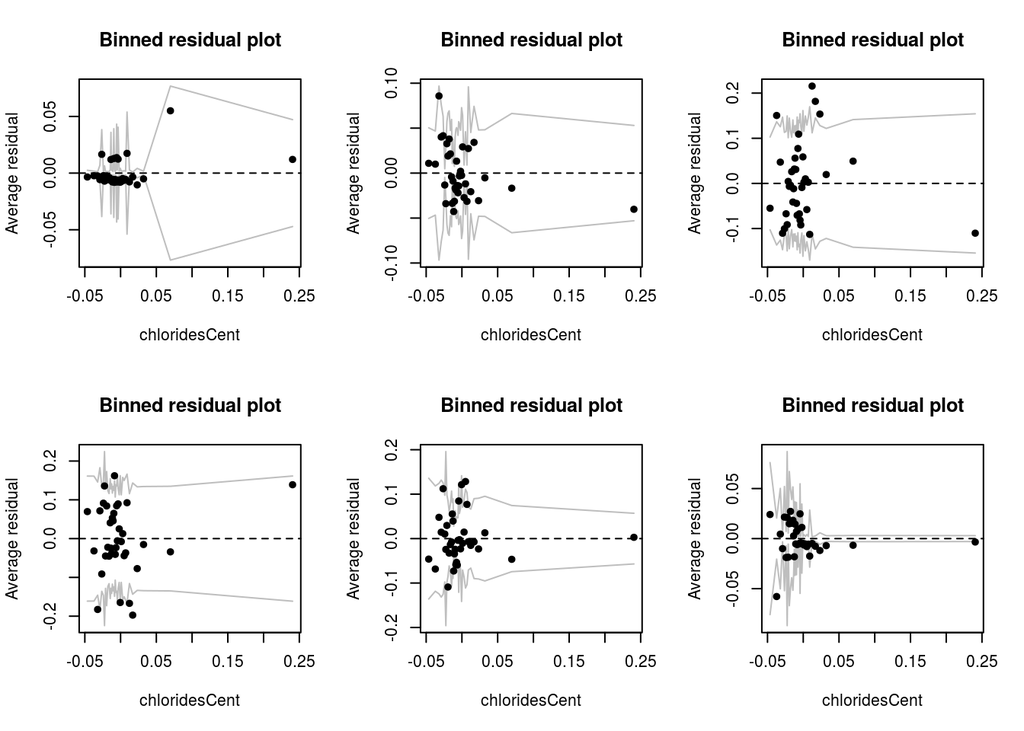

```r
# binned residual plots of chloridesCent for each category of quality
par(mfrow=c(2,3))
arm::binnedplot(x=data$chloridesCent,y=data$resid3,xlab="chloridesCent")
arm::binnedplot(x=data$chloridesCent,y=data$resid4,xlab="chloridesCent")
arm::binnedplot(x=data$chloridesCent,y=data$resid5,xlab="chloridesCent")
arm::binnedplot(x=data$chloridesCent,y=data$resid6,xlab="chloridesCent")
arm::binnedplot(x=data$chloridesCent,y=data$resid7,xlab="chloridesCent")
arm::binnedplot(x=data$chloridesCent,y=data$resid8,xlab="chloridesCent")
```

The binned residual plots show a possible chloridesCent outlier.

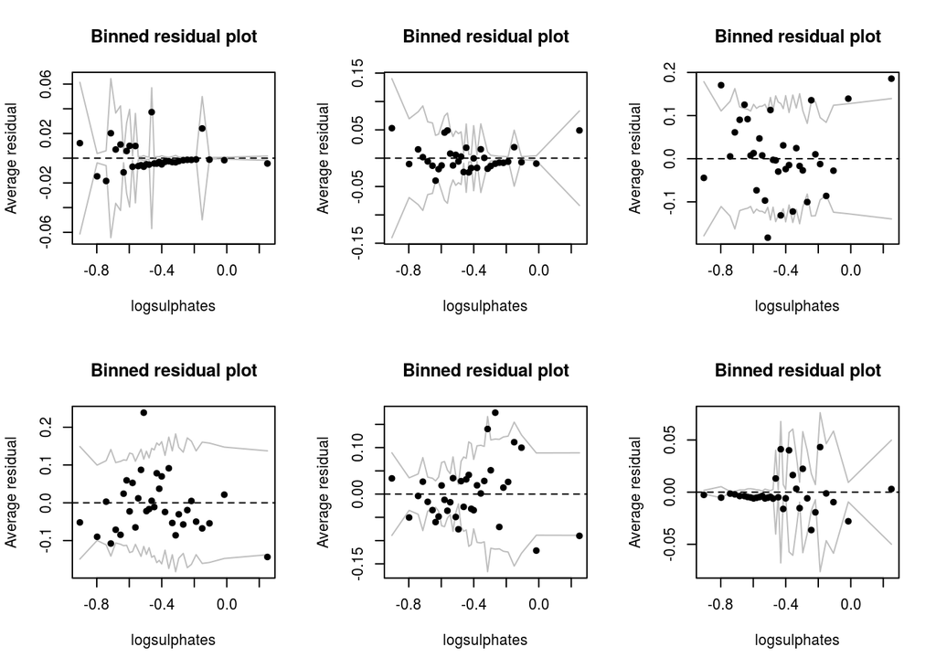

```r
# binned residual plots of sulphatesCent for each category of quality
par(mfrow=c(2,3))
arm::binnedplot(x=data$logsulphates,y=data$resid3,xlab="logsulphates")
arm::binnedplot(x=data$logsulphates,y=data$resid4,xlab="logsulphates")
arm::binnedplot(x=data$logsulphates,y=data$resid5,xlab="logsulphates")
arm::binnedplot(x=data$logsulphates,y=data$resid6,xlab="logsulphates")
arm::binnedplot(x=data$logsulphates,y=data$resid7,xlab="logsulphates")
arm::binnedplot(x=data$logsulphates,y=data$resid8,xlab="logsulphates")
```

The log transformation of logsulphates has slightly improved its binned residual plots. But in the binned residual plot of quality at or below level 7 or otherwise still show potential linear trend.

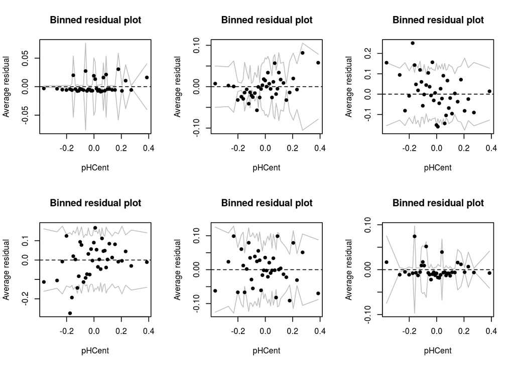

```r
# binned residual plots of pHCent for each category of quality
par(mfrow=c(2,3))
arm::binnedplot(x=data$pHCent,y=data$resid3,xlab="pHCent")
arm::binnedplot(x=data$pHCent,y=data$resid4,xlab="pHCent")
arm::binnedplot(x=data$pHCent,y=data$resid5,xlab="pHCent")
arm::binnedplot(x=data$pHCent,y=data$resid6,xlab="pHCent")
arm::binnedplot(x=data$pHCent,y=data$resid7,xlab="pHCent")
arm::binnedplot(x=data$pHCent,y=data$resid8,xlab="pHCent")
```

Some of the binned residual plots with pHCent sugget potential linear trend, but the non-randomness is not very obvious, thus not too concerning.

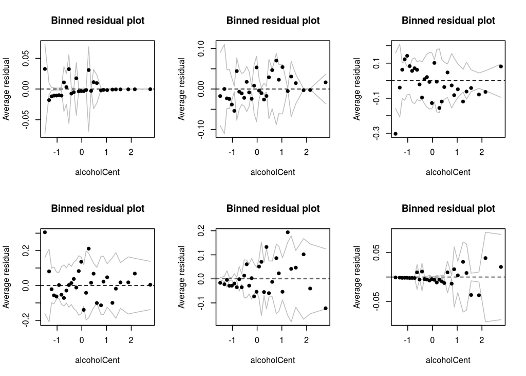

```r
# binned residual plots of alcohol.Cent for each category of quality
par(mfrow=c(2,3))
arm::binnedplot(x=data$alcoholCent,y=data$resid3,xlab="alcoholCent")
arm::binnedplot(x=data$alcoholCent,y=data$resid4,xlab="alcoholCent")
arm::binnedplot(x=data$alcoholCent,y=data$resid5,xlab="alcoholCent")
arm::binnedplot(x=data$alcoholCent,y=data$resid6,xlab="alcoholCent")
arm::binnedplot(x=data$alcoholCent,y=data$resid7,xlab="alcoholCent")
arm::binnedplot(x=data$alcoholCent,y=data$resid8,xlab="alcoholCent")
```

The binned residual plots of alcoholCent for wines with quality at or below 6 appear to have a nonrandom pattern. The plot for wines with quality at or below 7 indicates strong fanning patterns.

```r
kable(tidy(vif(final.model)))
```

```
##
## Re-fitting to get Hessian
```

| names | x |
| --- | --- |
| volatile.acidityCent | 6.310810 |
| citric.acid | 1.314155 |
| chloridesCent | 6.902109 |
| logsulphates | 1.574871 |
| pHCent | 1.484354 |
| alcoholCent | 1.618167 |

VIF measures is still below 10 for all variables, so no concerning multicollinearity in the model.

## Model Fit

```r
# predicted categories for confusion matrix
data <- data %>% mutate(pred.comp = predict(final.model,type="class")) # get predicted categories
result <- data %>% group_by(pred.comp,quality_dup) %>% summarise(n=n()) # summarise actual vs. predicted
kable(spread(result,quality_dup,n),format="markdown") # print actual vs. predicted categories
```

| pred.comp | 3 | 4 | 5 | 6 | 7 | 8 |
| --- | --- | --- | --- | --- | --- | --- |
| 4 | 1 | NA | NA | NA | NA | NA |
| 5 | 8 | 41 | 513 | 219 | 11 | NA |
| 6 | 1 | 12 | 164 | 389 | 139 | 11 |
| 7 | NA | NA | 3 | 30 | 49 | 7 |
| 8 | NA | NA | 1 | NA | NA | NA |

```r
# misclassification rate
(10+53+168+249+150+18)/1599
```

```
## [1] 0.4052533
```

The misclassification rate of the model is around 40.5%. We can see that the model does not predict any quality at level 3, most likely because there are only 10 such observations in the data set. The model predicts quality level 5 and 6 pretty well. We also remember from the exploratory data analysis, most of the observations are around quality level 5 and 6. Overall, the model is pretty good.

```r
# obtain p-values of the final model
tidy(coeftest(final.model))
```

```
##
## Re-fitting to get Hessian
```

```
## # A tibble: 11 x 5
##    term                 estimate std.error statistic   p.value
##    <chr>                   <dbl>     <dbl>     <dbl>     <dbl>
##  1 volatile.acidityCent   -3.47     0.379      -9.16 5.13e- 20
##  2 citric.acid            -0.910    0.377      -2.41 1.59e-  2
##  3 chloridesCent          -5.61     1.29       -4.36 1.30e-  5
##  4 logsulphates            2.50     0.267       9.35 8.42e- 21
##  5 pHCent                 -1.68     0.416      -4.03 5.52e-  5
##  6 alcoholCent             0.943    0.0581     16.2  2.28e- 59
##  7 3|4                    -7.31     0.378     -19.4  1.94e- 83
##  8 4|5                    -5.35     0.235     -22.8  6.92e-115
##  9 5|6                    -1.65     0.178      -9.32 1.18e- 20
## 10 6|7                     1.19     0.179       6.67 2.55e- 11
## 11 7|8                     4.23     0.289      14.6  2.47e- 48
```